### 10월/5주

#### ▶ 정당지지도

더불어민주당 45.6%, 국민의힘 33.2%, 조국혁신당 5.7%, 개혁신당 3.1%, 기타 정당 2.0%, 지지하는 정당 없다 9.5%, 잘 모르겠다 0.9%

#### ▶ 국정평가

잘하고 있다 23.9%, 잘못하고 있다 73.6%, 잘 모르겠다 2.5%

#### ☑ 차기 대권 주자 적합도

김동연 3.2%, 안철수 2.1%, 오세훈 5.2%, 원희룡 3.5%, 이재명 45.0%, 이준석 4.8%, 조국 5.6%, 한동훈 18.6%, 홍준표 4.3%, 그 외 인물 1.5%, 없다 4.1%, 잘 모르겠다 2.1%

#### ☑ 윤석열 대통령 발언 적절성

매우 적절하다 13.7%, 대체로 적절한 편이다 9.8%, 대체로 적절하지 않다 8.8%, 매우 적절하지 않다 64.2%, 잘 모르겠다 3.5%

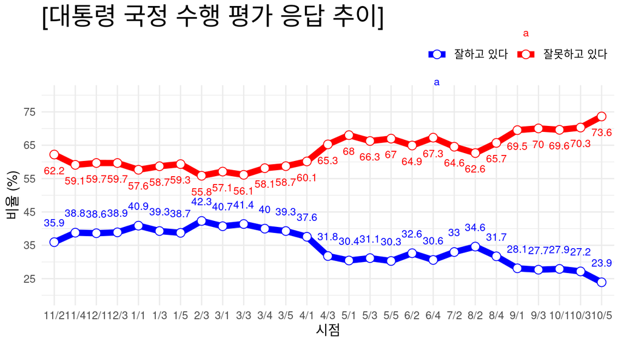

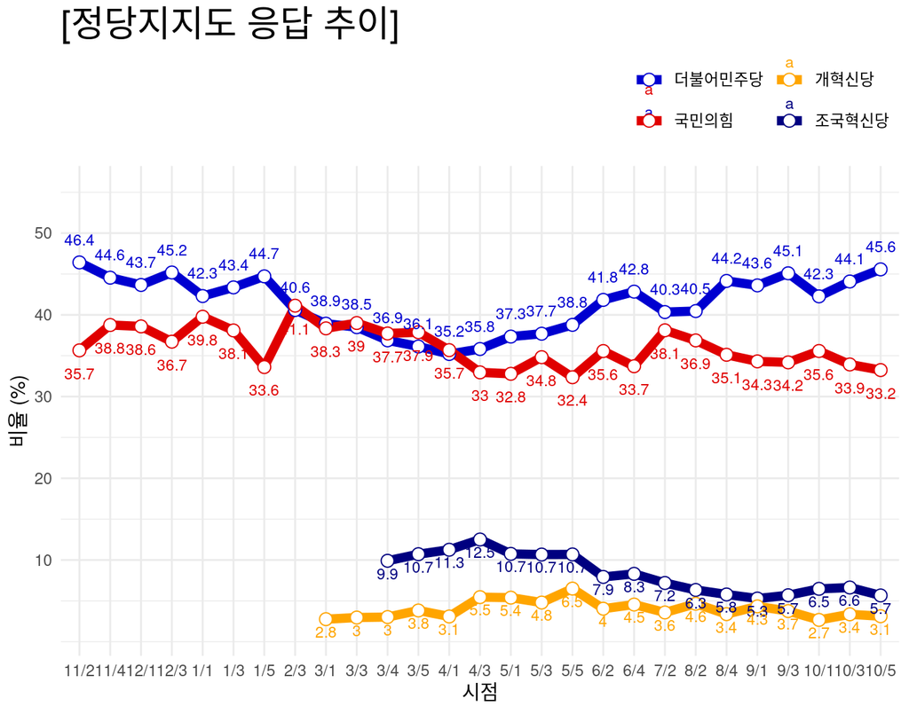

### 추가사항

- [주요질문 / 집단별 세부통계 보기](https://modernity.shinyapps.io/survey_str/) (링크누르시오)

### 참고사항

- 표본수: 2,000명,표본오차는 95% ±2.2%p
- 조사정보: 스트레이트뉴스의 의뢰로 조원씨앤아이가 2024년 10월 26일~28일 3일간

  전국 만 18세 이상 남녀를 대상으로 ARS 여론조사

  (휴대전화 100% RDD 방식, 성,연령대,지역별 비례할당 후 무작위 추출)를 실시한 결과이며,

  표본수는 2,000(총 통화시도 79,742명, 응답률 2.5%)

  ※ 가중치 부여 방식: [림가중] 성별, 연령별, 지역별 가중값 부여(2024년 9월말 행정안전부 발표 주민등록인구기준)
- [중앙선거여론조사심의위원회](https://nesdc.go.kr/portal/bbs/B0000005/list.do?menuNo=200467)에서 관련사항 확인가능

2024.11.08 (금) 16:51 제작

- 연구개발 단계입니다.
- 제공: 감동과 마음의 [조원씨앤아이](http://jowoncni.com/html/index.html)